# Report of Exploration into UN Data and Worldwide Internet Usage - Part 2

Shirlett Hall  
November 14, 2017

- Statistical Analysis and Figures
- Linear Regression

```r
options(warn = -1)
options(message = -1)
suppressWarnings(suppressMessages(library(tidyverse)))
suppressWarnings(suppressMessages(library(dplyr)))
suppressWarnings(suppressMessages(library(gridExtra)))
suppressWarnings(suppressMessages(library(scales)))
suppressWarnings(suppressMessages(library(maps)))
suppressWarnings(suppressMessages(library(maptools)))

setwd("~/myrepositories/STAT545-hw-Hall-Shirlett/HW07")
library('tidyverse')
library(knitr)
```

for formatting the output of tables

```r
library(dplyr)
```

for grouping and filtering

```r
library(forcats)
```

used to manipulate factors for ordering, lumping etc

```r
library(gridExtra)
```

used to layout tables and charts in a grid

```r
library(grid)
```

used to layout tables and charts in a grid

```r
library(readxl)
```

used to read excel file formats

```r
library(RColorBrewer)
```

has a set of colors for print and graphics

```r
library(scales)
```

to modify the appearance of axis values and colors

```r
library(ggthemes)
```

additional color themes

```r
library(devtools)
```

used to save figures

```r
library(ggplot2)
library(maps)
library(ggmap)
library(maptools)
library(stringr) #for replacement of strings in dataset columns
library(broom) # to tidy printed summary output and convert to a dataframe
library(gridExtra) #used to layout tables and charts in a grid
library(grid) #used to layout tables and charts in a grid
setwd("~/myrepositories/STAT545-hw-Hall-Shirlett/HW07")
```

# Statistical Analysis and Figures

```r
library(readr)
All_Data <- read_csv("./All_Data.csv")
```

Get median values for number of Internet Users and Urban Density

```r
Internet_Urban <- All_Data %>%
    select(Year, Internet_Users_per_100, Percent_urban) %>%
    group_by(Year) %>%
    summarise(Med_Internet_Users=median(Internet_Users_per_100), Med_Percent_urban=median(Percent_urban, na.rm = TRUE))
```

Get estimate of slopes, intercepts for linear model

```r
urbanfit <- tidy(lm(Med_Internet_Users ~ Med_Percent_urban, data = Internet_Urban))
kable(urbanfit)
```

| term | estimate | std.error | statistic | p.value |
| --- | --- | --- | --- | --- |
| (Intercept) | -77.338166 | 44.7782513 | -1.727137 | 0.1348876 |
| Med_Percent_urban | 1.908213 | 0.7502498 | 2.543437 | 0.0438771 |

Capture p-value to pass to graph

```r
pval <- toString(round(urbanfit[2,5], digits=5))
```

# Linear Regression

```r
Urban_plot <- Internet_Urban %>%
    ggplot(aes(Med_Percent_urban, Med_Internet_Users)) +
    geom_point(shape=1) +
    geom_smooth(method=lm) +
    labs(
        subtitle="Internet Usage and Urban Density, 2008-15",
        caption="source: UN",
        y = "Median Number of Internet Users per 100 inhabitants per Year", x= "Median Percent of Populations living in Urban Areas") +
    theme(plot.subtitle = element_text(size = 15)) +
    annotate("text", x=65, y=10, label = paste("p-value=", pval), parse=F)

ggsave("./img/Urban_plot.png", Urban_plot, width = 14, height=15, units="cm", scale=1)
```

The graph below shows that there is a positive relationship between Internet usage and urban density. With a value less than 0.05, the p-value also indicates that this relationship is significant.

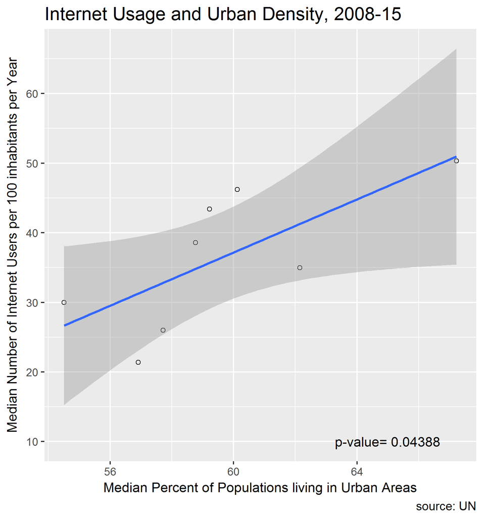

Get median values for number of Internet Users and Gross National Income

```r
Internet_GNI <- All_Data %>%
    select(Year, Internet_Users_per_100, GNI_per_cap) %>%
    group_by(Year) %>%
    summarise(Med_Internet_Users=median(Internet_Users_per_100), Med_GNI=median(GNI_per_cap, na.rm = TRUE))
```

Get estimate of slopes, intercepts for linear model

```r
gnifit <- tidy(lm(Med_Internet_Users ~ Med_GNI, data = Internet_GNI))
kable(gnifit)
```

| term | estimate | std.error | statistic | p.value |
| --- | --- | --- | --- | --- |
| (Intercept) | -43.631663 | 12.3925241 | -3.520805 | 0.0125063 |
| Med_GNI | 0.015245 | 0.0023478 | 6.493411 | 0.0006347 |

Capture p-value to pass to graph

```r
pgni <- toString(round(gnifit[2,5], digits=5))
```

Linear Regression

```r
GNI_plot <- Internet_GNI %>%
    ggplot(aes(Med_GNI, Med_Internet_Users)) +
    geom_point(shape=1) +
    geom_smooth(method=lm) +
    labs(
        subtitle="Internet Usage and Gross National Income, 2008-15",
        caption="source: UN",
        y = "Median Number of Internet Users per 100 inhabitants per Year", x= "Median Gross National Income per Capita") +
    theme(plot.subtitle = element_text(size = 15)) +
    annotate("text", x=5900, y=10, label = paste("p-value=", pgni), parse=F)


ggsave("./img/GNI_plot.png", GNI_plot, width = 14, height=15, units="cm", scale=1)
```

The graph below shows that there is a positive relationship between Internet usage and GNI. With a value less than 0.05, the p-value also indicates that this relationship is significant.

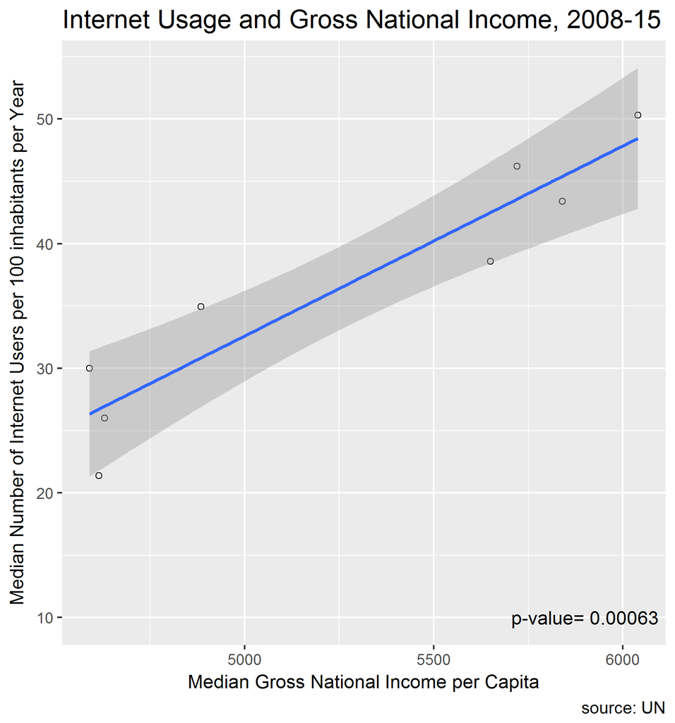

Get median values for number of Internet Users and Access to Electricity

```r
Internet_Electricity <- All_Data %>%
    select(Year, Internet_Users_per_100, Per_Access_Electricity) %>%
    group_by(Year) %>%
    summarise(Med_Internet_Users=median(Internet_Users_per_100), Med_Percent_Electricity=median(Per_Access_Electricity, na.rm = TRUE))
```

Get estimate of slopes, intercepts for linear model using the broom package to present results

```r
electfit <- tidy(lm(Med_Internet_Users ~ Med_Percent_Electricity, data = Internet_Electricity))
kable(electfit)
```

| term | estimate | std.error | statistic | p.value |
| --- | --- | --- | --- | --- |
| (Intercept) | -1582.21071 | 212.649779 | -7.440453 | 0.0006914 |
| Med_Percent_Electricity | 16.34516 | 2.150084 | 7.602101 | 0.0006256 |

Capture p-value to pass to graph

```r
pelec <- toString(round(electfit[2,5], digits=5))
```

Linear Regression

```r
Elect_plot <- Internet_Electricity %>%
    ggplot(aes(Med_Percent_Electricity, Med_Internet_Users)) +
    geom_point(shape=1) +
    geom_smooth(method=lm) +
    labs(
        subtitle="Internet Usage and Access to Electricity, 2008-15",
        caption="source: UN",
        y = "Median Number of Internet Users per 100 inhabitants per Year", x= "Median Percent of Populations with Access to Electricity") +
    theme(plot.subtitle = element_text(size = 15)) +
    annotate("text", x=99, y=10, label = paste("p-value=", pelec), parse=F)


ggsave("./img/Elect_plot.png", Elect_plot, width = 14, height=15, units="cm", scale=1)
```

The graph below shows that there is a positive relationship between Internet usage and the percentage of persons with access to elecricity. With a value less than 0.05, the p-value also indicates that this relationship is significant.

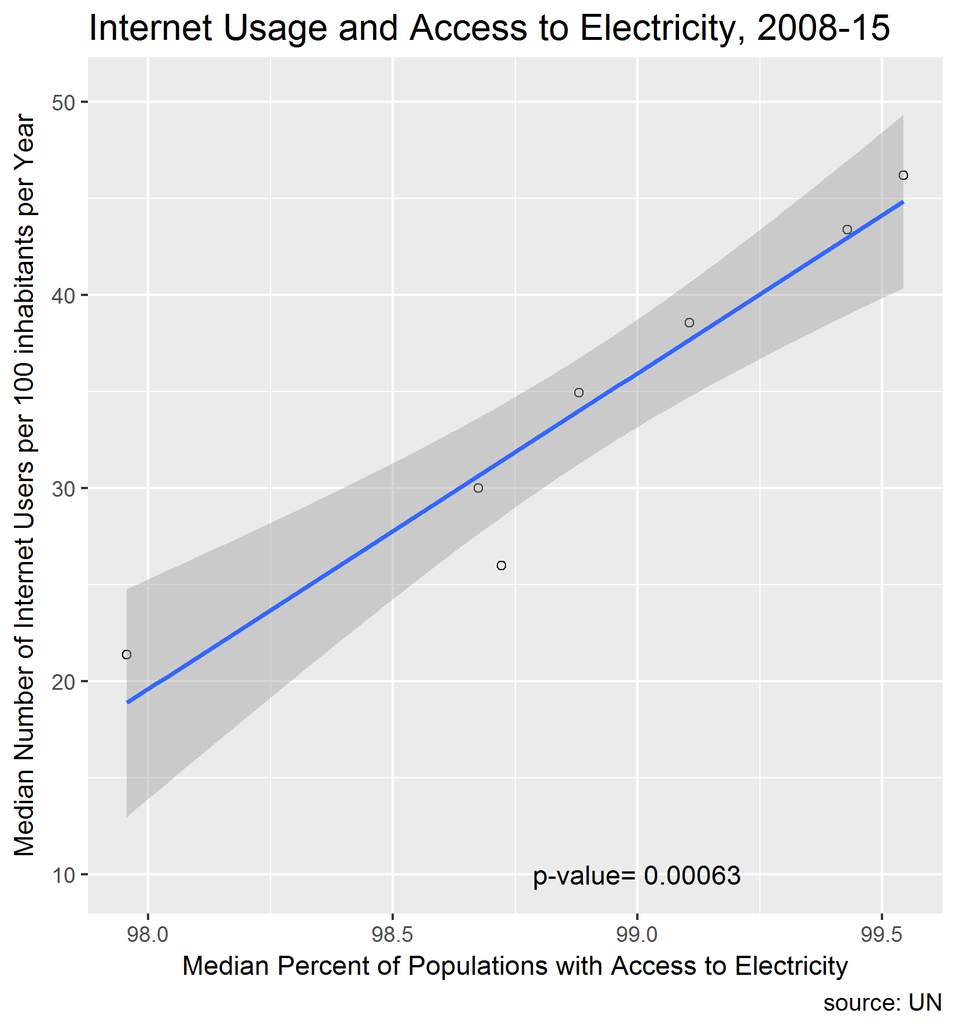

Get median values for number of Internet Users and Life Expectancy

```r
Internet_Life <- All_Data %>%
    select(Year, Internet_Users_per_100, Median_Life_Exp) %>%
    group_by(Year) %>%
    summarise(Med_Internet_Users=median(Internet_Users_per_100), Med_Life=median(Median_Life_Exp, na.rm = TRUE))
```

Get estimate of slopes, intercepts for linear model

```r
lifefit <- tidy(lm(Med_Internet_Users ~ Med_Life, data = Internet_Life))
kable(lifefit)
```

| term | estimate | std.error | statistic | p.value |
| --- | --- | --- | --- | --- |
| (Intercept) | -1344.51966 | 167.669309 | -8.018878 | 0.0004875 |
| Med_Life | 18.88899 | 2.296836 | 8.223914 | 0.0004330 |

Capture p-value to pass to graph

```r
plife <- toString(round(lifefit[2,5], digits=5))
```

Linear Regression

```r
Life_plot <- Internet_Life %>%
    ggplot(aes(Med_Life, Med_Internet_Users)) +
    geom_point(shape=1) +
    geom_smooth(method=lm) +
    labs(
        subtitle="Internet Usage and Median Life Expectancy, 2008-15",
        caption="source: UN",
        y = "Median Number of Internet Users per 100 inhabitants per Year", x= "Median Life Expectancy") +
    theme(plot.subtitle = element_text(size = 15)) +
    annotate("text", x=73, y=10, label = paste("p-value=", plife), parse=F)


ggsave("./img/Life_plot.png", Life_plot, width = 14, height=15, units="cm", scale=1)
```

The graph below shows that there is a positive relationship between Internet usage and median life expectancy. With a value less than 0.05, the p-value also indicates that this relationship is significant. Of all the four factors, this relationship has the lowest p-value and will be expanded in Part 3.

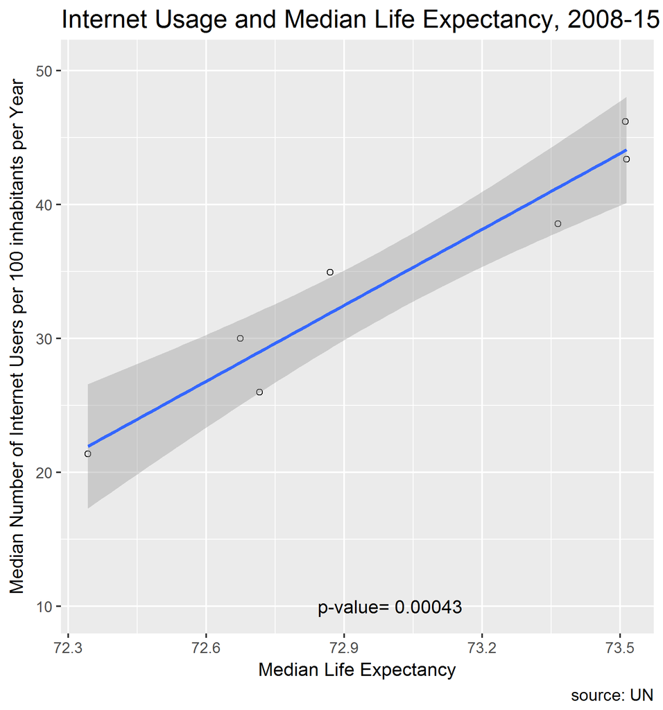

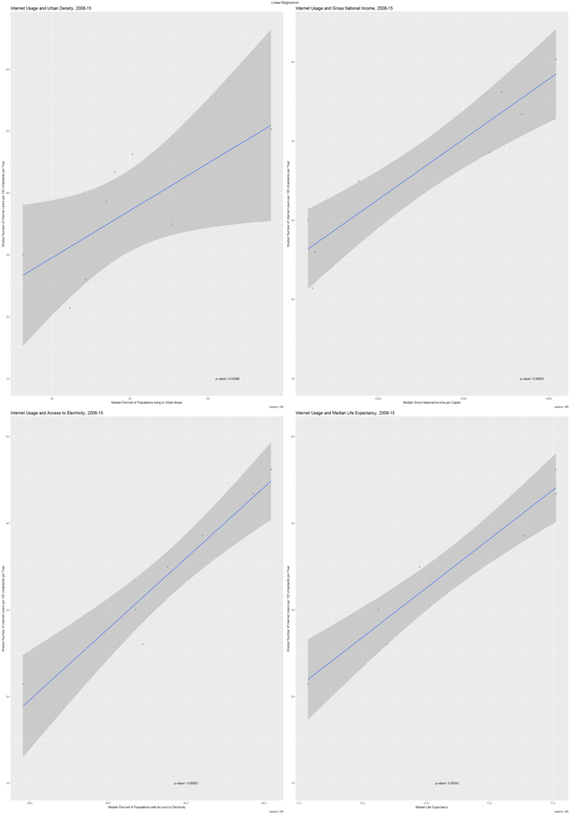

```r
#Arrange the figures in a grid
internet_grid <- grid.arrange(Urban_plot, GNI_plot, Elect_plot, Life_plot,
                                                            ncol=2,
                                                            as.table=TRUE,
                                                            heights=c(15,15),
                                                            widths=c(13, 13),
                                                            top="Linear Regression")
```

```r
ggsave("./img/internet_grid.png", internet_grid, width = 28, height=40, units="cm", scale=1)
```